# Human Activity Recognition using Machine Learning

Filippo Miramonti

11/8/2020

## Background

Using devices such as Jawbone Up, Nike FuelBand, and Fitbit it is now possible to collect a large amount of data about personal activity relatively inexpensively. The goal of this project is to predict the manner in which partecipants did the barbell lift. The data for this project come from: http://groupware.les.inf.puc-rio.br/har. In this project, the goal is to use data from accelerometers on the belt, forearm, arm, and dumbell of 6 participants. They were asked to perform barbell lifts correctly and incorrectly in 5 different ways.

### Project structure:

- Data Preprocessing
- Exploratory Analysis
- Prediction Model Selection
- Predicting Test Data Output

## Data Preprocessing

First of all I load the training and the testing datasets from the source URLs and split the training dataset into train and test sets.

```r
library(caret)
training <- read.csv("https://d396qusza40orc.cloudfront.net/predmachlearn/pml-training.csv")
testing <- read.csv("https://d396qusza40orc.cloudfront.net/predmachlearn/pml-testing.csv")

inTrain <- createDataPartition(y = training$classe, p=0.7, list=FALSE)
train <- training[inTrain,]
test <- training[-inTrain,]
train$classe <- as.factor(train$classe)
test$classe <- as.factor(test$classe)
```

From 160 variables present in the dataset, some have a lot of NAs and should be excluded. Moreover, the first seven variables are only used for identification and should be excluded too.

```r
train <- train[, 8:ncol(train)]
train[train == "" ] <- NA
test[test == "" ] <- NA
train <- train[, colSums(is.na(train)) < nrow(train) * 0.95]
test <- test[, colnames(train)]
```

The result of the data preprocessing is that there are 53 variables left.

## Exploratory Analysis

Now that I have cleaned dataset, removing useless variables, I can investigate the correlation between these variables using a correlation plot:

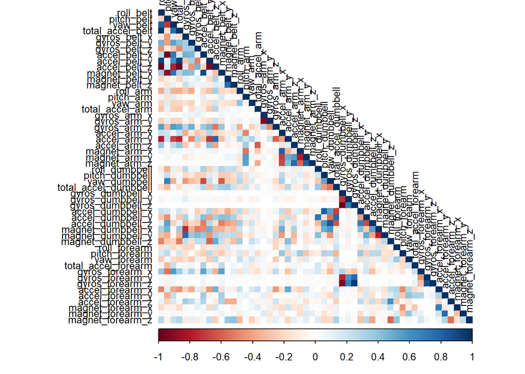

```r
library(corrplot)
corMatrix <- cor(train[,-53])
corrplot(corMatrix, method = "color", tl.col = rgb(0,0,0), type = "lower", tl.cex = 0.8)
```

It’s easy to see in the plot above, where darker gradient correspond to having higher correlation, that there are few areas where the correlation is high: it isn’t necessary to run the Principal Component Analysis(PCA) in order to reduce the correlated variables.

## Prediction Model Selection

To select the model I will use three methods(Decision Tree, Random Forest and Generalized Boosted Model) and I will choose the one who have the best accuracy to predict the outcome variable in the testing set.

### Decision Tree

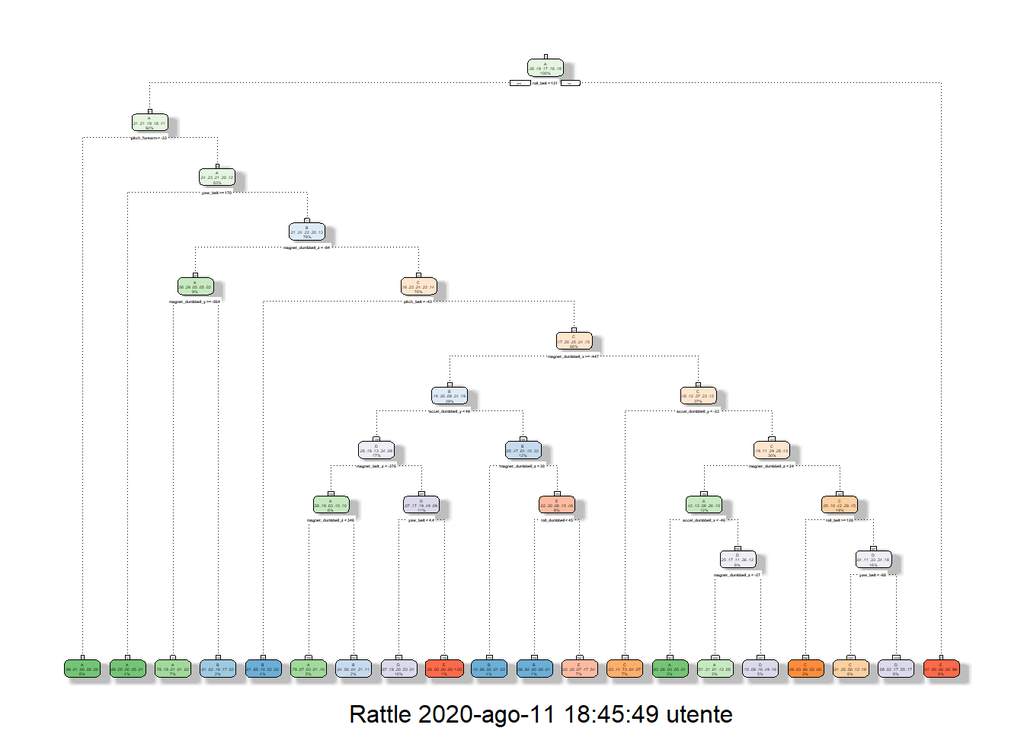

```r
library(rpart)
library(rattle)
set.seed(110820)
fitDT <- rpart(classe ~ ., data = train)
fancyRpartPlot(fitDT)
```

```r
predDT <- predict(fitDT, test, type = "class")
confusionMatrix(predDT, test$classe)
```

```
## Confusion Matrix and Statistics
##
##           Reference
## Prediction    A    B    C    D    E
##          A 1465  197   26   64   58
##          B   34  590   42   76   41
##          C   28  139  667   74  111
##          D  133  143  264  704  127
##          E   14   70   27   46  745
##
## Overall Statistics
##
##                Accuracy : 0.7088
##                  95% CI : (0.697, 0.7203)
##     No Information Rate : 0.2845
##     P-Value [Acc > NIR] : < 2.2e-16
##
##                   Kappa : 0.6314
##
##  Mcnemar's Test P-Value : < 2.2e-16
##
## Statistics by Class:
##
##                      Class: A Class: B Class: C Class: D Class: E
## Sensitivity            0.8751   0.5180   0.6501   0.7303   0.6885
## Specificity            0.9181   0.9593   0.9276   0.8645   0.9673
## Pos Pred Value         0.8094   0.7535   0.6546   0.5135   0.8259
## Neg Pred Value         0.9487   0.8924   0.9262   0.9424   0.9324
## Prevalence             0.2845   0.1935   0.1743   0.1638   0.1839
## Detection Rate         0.2489   0.1003   0.1133   0.1196   0.1266
## Detection Prevalence   0.3076   0.1331   0.1732   0.2330   0.1533
## Balanced Accuracy      0.8966   0.7387   0.7888   0.7974   0.8279
```

### Random Forest

```r
control <- trainControl(method = "cv", number = 3, verboseIter=FALSE)
fitRF <- train(classe ~ ., data = train, method = "rf", trControl = control)
fitRF$finalModel
```

```
##
## Call:
##  randomForest(x = x, y = y, mtry = param$mtry)
##                Type of random forest: classification
##                      Number of trees: 500
## No. of variables tried at each split: 27
##
##         OOB estimate of  error rate: 0.68%
## Confusion matrix:
##      A    B    C    D    E class.error
## A 3902    2    1    0    1 0.001024066
## B   17 2636    4    1    0 0.008276900
## C    0   16 2373    7    0 0.009599332
## D    0    1   27 2221    3 0.013765542
## E    0    2    3    8 2512 0.005148515
```

```r
predRF <- predict(fitRF, test)
confusionMatrix(predRF, test$classe)
```

```
## Confusion Matrix and Statistics
##
##           Reference
## Prediction    A    B    C    D    E
##          A 1673    9    0    0    0
##          B    0 1126    3    0    0
##          C    1    4 1021    5    1
##          D    0    0    2  958    4
##          E    0    0    0    1 1077
##
## Overall Statistics
##
##                Accuracy : 0.9949
##                  95% CI : (0.9927, 0.9966)
##     No Information Rate : 0.2845
##     P-Value [Acc > NIR] : < 2.2e-16
##
##                   Kappa : 0.9936
##
##  Mcnemar's Test P-Value : NA
##
## Statistics by Class:
##
##                      Class: A Class: B Class: C Class: D Class: E
## Sensitivity            0.9994   0.9886   0.9951   0.9938   0.9954
## Specificity            0.9979   0.9994   0.9977   0.9988   0.9998
## Pos Pred Value         0.9946   0.9973   0.9893   0.9938   0.9991
## Neg Pred Value         0.9998   0.9973   0.9990   0.9988   0.9990
## Prevalence             0.2845   0.1935   0.1743   0.1638   0.1839
## Detection Rate         0.2843   0.1913   0.1735   0.1628   0.1830
## Detection Prevalence   0.2858   0.1918   0.1754   0.1638   0.1832
## Balanced Accuracy      0.9986   0.9940   0.9964   0.9963   0.9976
```

### Generalized Boosted Model

```r
control <- trainControl(method = "repeatedcv", number = 5, repeats = 2, verboseIter = FALSE)
fitGBM <- train(classe ~ ., data = train, method = "gbm", verbose = FALSE, trControl = control)
fitGBM$finalModel
```

```
## A gradient boosted model with multinomial loss function.
## 150 iterations were performed.
## There were 52 predictors of which 52 had non-zero influence.
```

```r
predGBM <- predict(fitGBM, test)
confusionMatrix(predGBM, test$classe)
```

```
## Confusion Matrix and Statistics
##
##           Reference
## Prediction    A    B    C    D    E
##          A 1654   42    0    0    1
##          B   11 1068   24    4   13
##          C    6   27  990   27    5
##          D    2    2   11  929   11
##          E    1    0    1    4 1052
##
## Overall Statistics
##
##                Accuracy : 0.9674
##                  95% CI : (0.9625, 0.9718)
##     No Information Rate : 0.2845
##     P-Value [Acc > NIR] : < 2.2e-16
##
##                   Kappa : 0.9587
##
##  Mcnemar's Test P-Value : 8.664e-08
##
## Statistics by Class:
##
##                      Class: A Class: B Class: C Class: D Class: E
## Sensitivity            0.9881   0.9377   0.9649   0.9637   0.9723
## Specificity            0.9898   0.9890   0.9866   0.9947   0.9988
## Pos Pred Value         0.9747   0.9536   0.9384   0.9728   0.9943
## Neg Pred Value         0.9952   0.9851   0.9925   0.9929   0.9938
## Prevalence             0.2845   0.1935   0.1743   0.1638   0.1839
## Detection Rate         0.2811   0.1815   0.1682   0.1579   0.1788
## Detection Prevalence   0.2884   0.1903   0.1793   0.1623   0.1798
## Balanced Accuracy      0.9889   0.9634   0.9758   0.9792   0.9855
```

## Predicting Test Data Output

```r
predRF <- predict(fitRF, testing)
predRF
```

```
##  [1] B A B A A E D B A A B C B A E E A B B B
## Levels: A B C D E
```